# Introduction to Machine Learning - Part 1

Data Exploration & Preprocessing

Gladstone Bioinformatics Core

2026-01-06

# Introduction

Welcome to the Introduction to Machine Learning workshop! In this first part, we’ll explore our dataset and prepare it for machine learning algorithms.

## Why Data Preprocessing Matters

Before applying any machine learning algorithm, it’s crucial to understand and prepare your data. Different ML algorithms have different requirements:

- **Missing data**: Most algorithms cannot handle missing values
- **Categorical variables**: May need to be encoded as numbers
- **Feature scaling**: Some algorithms are sensitive to the scale of features

**Key takeaway:** Always clean and preprocess your data before applying ML algorithms!

# Load Required Libraries

```r
# Data manipulation
library(tidyverse)

# Visualization
library(ggplot2)

# For summary statistics
library(skimr)

# For missing data visualization
library(naniar)
```

# Load the Data

We’ll be using a COVID-19 symptoms dataset. This dataset contains patient symptoms and their COVID test results.

```r
# Set the path to your data file
# Modify this path if needed
data_path <- "data/covid-symptoms.csv"

# Load the data
covid_data <- read.csv(data_path)

# Quick look at the data
head(covid_data)
```

```
##   covid19_test_results temperature high_risk_exposure_occupation
## 1             Negative       37.20                             0
## 2             Negative       36.95                             0
## 3             Negative       37.00                             0
## 4             Negative       36.85                             0
## 5             Negative       37.10                             0
## 6             Negative          NA                             0
##   high_risk_interactions labored_respiration rhonchi cough cough_severity fever
## 1                      1                   0       1     0                    0
## 2                      1                   0       0     0                    0
## 3                      0                  NA      NA     0                    0
## 4                     NA                  NA      NA     0                   NA
## 5                      0                   0       0     0                    0
## 6                      0                  NA      NA     0                    0
##   sob diarrhea fatigue headache loss_of_smell loss_of_taste runny_nose
## 1   0        0       0        0             0             0          0
## 2   0        0       0        0             0             0          0
## 3   0        0       0        1             0             0          0
## 4   0        0       0        0             0             0          0
## 5   0        0       0        0             0             0          0
## 6   0        0       0        0             0             0          0
##   muscle_sore sore_throat wheezes
## 1           0           0       1
## 2           0           0       0
## 3           1           0      NA
## 4           0           0      NA
## 5           0           0       0
## 6           0           0      NA
```

```r
# Check dimensions
cat("Number of rows:", nrow(covid_data), "\n")
```

```
## Number of rows: 3045
```

```r
cat("Number of columns:", ncol(covid_data), "\n")
```

```
## Number of columns: 19
```

# Explore the Data Structure

## Column Types and Summary

```r
# View structure
str(covid_data)
```

```
## 'data.frame':    3045 obs. of  19 variables:
##  $ covid19_test_results         : chr  "Negative" "Negative" "Negative" "Negative" ...
##  $ temperature                  : num  37.2 37 37 36.9 37.1 ...
##  $ high_risk_exposure_occupation: int  0 0 0 0 0 0 0 1 0 0 ...
##  $ high_risk_interactions       : num  1 1 0 NA 0 0 0 0 0 0 ...
##  $ labored_respiration          : num  0 0 NA NA 0 NA 0 0 NA 0 ...
##  $ rhonchi                      : num  1 0 NA NA 0 NA NA 0 NA 0 ...
##  $ cough                        : int  0 0 0 0 0 0 0 0 0 0 ...
##  $ cough_severity               : chr  "" "" "" "" ...
##  $ fever                        : num  0 0 0 NA 0 0 0 0 0 0 ...
##  $ sob                          : int  0 0 0 0 0 0 0 0 0 0 ...
##  $ diarrhea                     : int  0 0 0 0 0 0 0 0 0 0 ...
##  $ fatigue                      : int  0 0 0 0 0 0 0 0 0 0 ...
##  $ headache                     : int  0 0 1 0 0 0 0 0 0 0 ...
##  $ loss_of_smell                : int  0 0 0 0 0 0 0 0 0 0 ...
##  $ loss_of_taste                : int  0 0 0 0 0 0 0 0 0 0 ...
##  $ runny_nose                   : int  0 0 0 0 0 0 1 0 0 0 ...
##  $ muscle_sore                  : int  0 0 1 0 0 0 0 0 0 0 ...
##  $ sore_throat                  : int  0 0 0 0 0 0 1 0 0 0 ...
##  $ wheezes                      : num  1 0 NA NA 0 NA NA 0 NA 0 ...
```

```r
# Summary statistics
summary(covid_data)
```

```
##  covid19_test_results  temperature    high_risk_exposure_occupation
##  Length:3045          Min.   :33.50   Min.   :0.0000
##  Class :character     1st Qu.:36.70   1st Qu.:0.0000
##  Mode  :character     Median :36.80   Median :0.0000
##                       Mean   :36.81   Mean   :0.1133
##                       3rd Qu.:36.95   3rd Qu.:0.0000
##                       Max.   :39.35   Max.   :1.0000
##                       NA's   :656
##  high_risk_interactions labored_respiration    rhonchi           cough
##  Min.   :0.0000         Min.   :0.00000     Min.   :0.0000   Min.   :0.0000
##  1st Qu.:0.0000         1st Qu.:0.00000     1st Qu.:0.0000   1st Qu.:0.0000
##  Median :0.0000         Median :0.00000     Median :0.0000   Median :0.0000
##  Mean   :0.2089         Mean   :0.00134     Mean   :0.1943   Mean   :0.0844
##  3rd Qu.:0.0000         3rd Qu.:0.00000     3rd Qu.:0.0000   3rd Qu.:0.0000
##  Max.   :1.0000         Max.   :1.00000     Max.   :1.0000   Max.   :1.0000
##  NA's   :235            NA's   :803         NA's   :2067
##  cough_severity         fever              sob            diarrhea
##  Length:3045        Min.   :0.00000   Min.   :0.0000   Min.   :0.00000
##  Class :character   1st Qu.:0.00000   1st Qu.:0.0000   1st Qu.:0.00000
##  Mode  :character   Median :0.00000   Median :0.0000   Median :0.00000
##                     Mean   :0.02678   Mean   :0.0532   Mean   :0.03284
##                     3rd Qu.:0.00000   3rd Qu.:0.0000   3rd Qu.:0.00000
##                     Max.   :1.00000   Max.   :1.0000   Max.   :1.00000
##                     NA's   :132
##     fatigue          headache       loss_of_smell     loss_of_taste
##  Min.   :0.0000   Min.   :0.00000   Min.   :0.00000   Min.   :0.00000
##  1st Qu.:0.0000   1st Qu.:0.00000   1st Qu.:0.00000   1st Qu.:0.00000
##  Median :0.0000   Median :0.00000   Median :0.00000   Median :0.00000
##  Mean   :0.0936   Mean   :0.09064   Mean   :0.01248   Mean   :0.01346
##  3rd Qu.:0.0000   3rd Qu.:0.00000   3rd Qu.:0.00000   3rd Qu.:0.00000
##  Max.   :1.0000   Max.   :1.00000   Max.   :1.00000   Max.   :1.00000
##
##    runny_nose       muscle_sore       sore_throat        wheezes
##  Min.   :0.00000   Min.   :0.00000   Min.   :0.0000   Min.   :0.000
##  1st Qu.:0.00000   1st Qu.:0.00000   1st Qu.:0.0000   1st Qu.:0.000
##  Median :0.00000   Median :0.00000   Median :0.0000   Median :0.000
##  Mean   :0.05386   Mean   :0.05714   Mean   :0.1051   Mean   :0.204
##  3rd Qu.:0.00000   3rd Qu.:0.00000   3rd Qu.:0.0000   3rd Qu.:0.000
##  Max.   :1.00000   Max.   :1.00000   Max.   :1.0000   Max.   :1.000
##                                                       NA's   :1849
```

## Using skimr for a Better Overview

```r
# Comprehensive summary with skimr
skim(covid_data)
```

Data summary

| Name | covid_data |
| --- | --- |
| Number of rows | 3045 |
| Number of columns | 19 |
| _______________________ |  |
| Column type frequency: |  |
| character | 2 |
| numeric | 17 |
| ________________________ |  |
| Group variables | None |

**Variable type: character**

| skim_variable | n_missing | complete_rate | min | max | empty | n_unique | whitespace |
| --- | --- | --- | --- | --- | --- | --- | --- |
| covid19_test_results | 0 | 1 | 8 | 8 | 0 | 2 | 0 |
| cough_severity | 0 | 1 | 0 | 8 | 2779 | 4 | 0 |

**Variable type: numeric**

| skim_variable | n_missing | complete_rate | mean | sd | p0 | p25 | p50 | p75 | p100 | hist |
| --- | --- | --- | --- | --- | --- | --- | --- | --- | --- | --- |
| temperature | 656 | 0.78 | 36.81 | 0.29 | 33.5 | 36.7 | 36.8 | 36.95 | 39.35 | ▁▁▇▂▁ |
| high_risk_exposure_occupation | 0 | 1.00 | 0.11 | 0.32 | 0.0 | 0.0 | 0.0 | 0.00 | 1.00 | ▇▁▁▁▁ |
| high_risk_interactions | 235 | 0.92 | 0.21 | 0.41 | 0.0 | 0.0 | 0.0 | 0.00 | 1.00 | ▇▁▁▁▂ |
| labored_respiration | 803 | 0.74 | 0.00 | 0.04 | 0.0 | 0.0 | 0.0 | 0.00 | 1.00 | ▇▁▁▁▁ |
| rhonchi | 2067 | 0.32 | 0.19 | 0.40 | 0.0 | 0.0 | 0.0 | 0.00 | 1.00 | ▇▁▁▁▂ |
| cough | 0 | 1.00 | 0.08 | 0.28 | 0.0 | 0.0 | 0.0 | 0.00 | 1.00 | ▇▁▁▁▁ |
| fever | 132 | 0.96 | 0.03 | 0.16 | 0.0 | 0.0 | 0.0 | 0.00 | 1.00 | ▇▁▁▁▁ |
| sob | 0 | 1.00 | 0.05 | 0.22 | 0.0 | 0.0 | 0.0 | 0.00 | 1.00 | ▇▁▁▁▁ |
| diarrhea | 0 | 1.00 | 0.03 | 0.18 | 0.0 | 0.0 | 0.0 | 0.00 | 1.00 | ▇▁▁▁▁ |
| fatigue | 0 | 1.00 | 0.09 | 0.29 | 0.0 | 0.0 | 0.0 | 0.00 | 1.00 | ▇▁▁▁▁ |
| headache | 0 | 1.00 | 0.09 | 0.29 | 0.0 | 0.0 | 0.0 | 0.00 | 1.00 | ▇▁▁▁▁ |
| loss_of_smell | 0 | 1.00 | 0.01 | 0.11 | 0.0 | 0.0 | 0.0 | 0.00 | 1.00 | ▇▁▁▁▁ |
| loss_of_taste | 0 | 1.00 | 0.01 | 0.12 | 0.0 | 0.0 | 0.0 | 0.00 | 1.00 | ▇▁▁▁▁ |
| runny_nose | 0 | 1.00 | 0.05 | 0.23 | 0.0 | 0.0 | 0.0 | 0.00 | 1.00 | ▇▁▁▁▁ |
| muscle_sore | 0 | 1.00 | 0.06 | 0.23 | 0.0 | 0.0 | 0.0 | 0.00 | 1.00 | ▇▁▁▁▁ |
| sore_throat | 0 | 1.00 | 0.11 | 0.31 | 0.0 | 0.0 | 0.0 | 0.00 | 1.00 | ▇▁▁▁▁ |
| wheezes | 1849 | 0.39 | 0.20 | 0.40 | 0.0 | 0.0 | 0.0 | 0.00 | 1.00 | ▇▁▁▁▂ |

# Understanding Our Variables

Let’s categorize our variables:

```r
# Target variable
cat("TARGET VARIABLE:\n")
```

```
## TARGET VARIABLE:
```

```r
cat("- covid19_test_results: The outcome we want to predict\n\n")
```

```
## - covid19_test_results: The outcome we want to predict
```

```r
# Check target distribution
table(covid_data$covid19_test_results)
```

```
##
## Negative Positive
##     2977       68
```

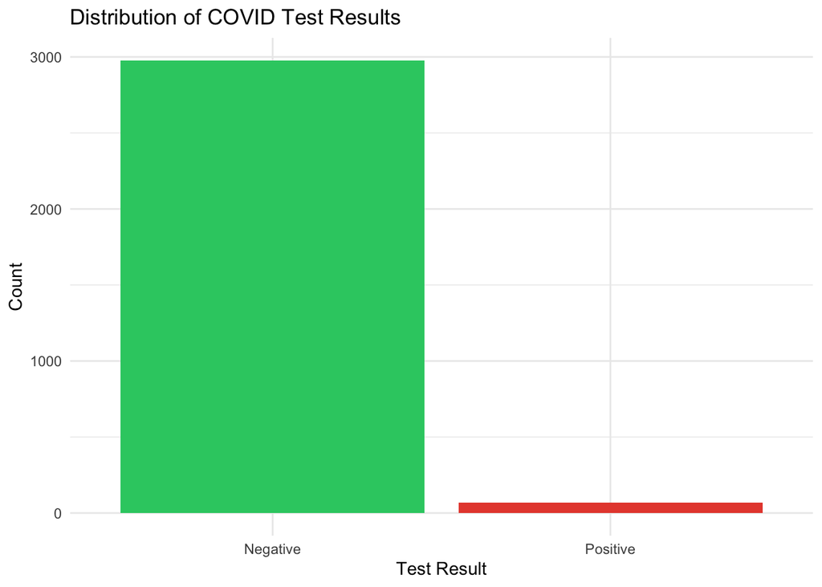

```r
# Visualize target distribution
ggplot(covid_data, aes(x = covid19_test_results, fill = covid19_test_results)) +
  geom_bar() +
  scale_fill_manual(values = c("Negative" = "#2ecc71", "Positive" = "#e74c3c")) +
  labs(title = "Distribution of COVID Test Results",
       x = "Test Result",
       y = "Count") +
  theme_minimal() +
  theme(legend.position = "none")
```

## Feature Variables

```r
# List all features
features <- setdiff(names(covid_data), "covid19_test_results")
cat("FEATURE VARIABLES:\n")
```

```
## FEATURE VARIABLES:
```

```r
cat(paste("-", features), sep = "\n")
```

```
## - temperature
## - high_risk_exposure_occupation
## - high_risk_interactions
## - labored_respiration
## - rhonchi
## - cough
## - cough_severity
## - fever
## - sob
## - diarrhea
## - fatigue
## - headache
## - loss_of_smell
## - loss_of_taste
## - runny_nose
## - muscle_sore
## - sore_throat
## - wheezes
```

# Handling Missing Data

## Visualize Missing Data

This is a crucial step! Let’s see how much data is missing.

```r
# Count missing values per column
missing_counts <- colSums(is.na(covid_data))
missing_pct <- round(100 * missing_counts / nrow(covid_data), 2)

missing_df <- data.frame(
  Variable = names(missing_counts),
  Missing_Count = missing_counts,
  Missing_Percent = missing_pct
) %>%
  arrange(desc(Missing_Count))

# Show variables with missing data
missing_df %>% filter(Missing_Count > 0)
```

```
##                                      Variable Missing_Count Missing_Percent
## rhonchi                               rhonchi          2067           67.88
## wheezes                               wheezes          1849           60.72
## labored_respiration       labored_respiration           803           26.37
## temperature                       temperature           656           21.54
## high_risk_interactions high_risk_interactions           235            7.72
## fever                                   fever           132            4.33
```

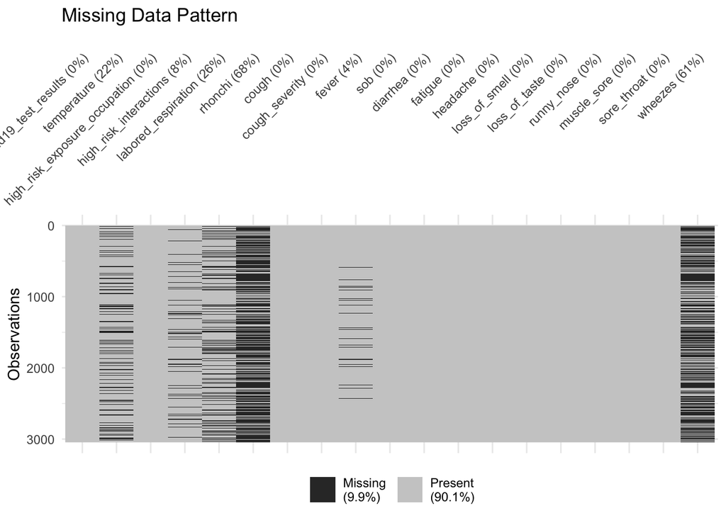

```r
# Visualize missing data pattern
vis_miss(covid_data) +
  labs(title = "Missing Data Pattern") +
  theme(axis.text.x = element_text(angle = 45, hjust = 1))
```

## Why Missing Data is a Problem

Most machine learning algorithms cannot handle missing values. We need to either: 1. Remove rows with missing values 2. Impute (fill in) the missing values

## Strategies for Handling Missing Data

### Strategy 1: Remove rows with missing values (Complete Case Analysis)

```r
# Remove all rows with any missing values
covid_complete <- covid_data %>%
  drop_na()

cat("Original rows:", nrow(covid_data), "\n")
```

```
## Original rows: 3045
```

```r
cat("After removing missing:", nrow(covid_complete), "\n")
```

```
## After removing missing: 844
```

```r
cat("Rows removed:", nrow(covid_data) - nrow(covid_complete), "\n")
```

```
## Rows removed: 2201
```

```r
cat("Percentage retained:", round(100 * nrow(covid_complete) / nrow(covid_data), 1), "%\n")
```

```
## Percentage retained: 27.7 %
```

**Pros:** Simple, no assumptions  
**Cons:** May lose a lot of data, may introduce bias if missingness is not random

### Strategy 2: Imputation (Replace with a value)

For numeric variables, common approaches: - **Mean imputation**: Replace with column mean - **Median imputation**: Replace with column median (better for skewed data) - **Mode imputation**: Replace with most common value (for categorical)

```r
# Create a copy for imputation
covid_imputed <- covid_data

# Identify numeric columns (excluding target)
numeric_cols <- names(covid_imputed)[sapply(covid_imputed, is.numeric)]

# Impute numeric columns with median
for (col in numeric_cols) {
  if (sum(is.na(covid_imputed[[col]])) > 0) {
    median_val <- median(covid_imputed[[col]], na.rm = TRUE)
    covid_imputed[[col]][is.na(covid_imputed[[col]])] <- median_val
    cat("Imputed", col, "with median:", median_val, "\n")
  }
}
```

```
## Imputed temperature with median: 36.8
## Imputed high_risk_interactions with median: 0
## Imputed labored_respiration with median: 0
## Imputed rhonchi with median: 0
## Imputed fever with median: 0
## Imputed wheezes with median: 0
```

```r
# Check if any missing values remain
cat("\nRemaining missing values:", sum(is.na(covid_imputed)), "\n")
```

```
##
## Remaining missing values: 0
```

# Handling Categorical Variables

## Identify Categorical Variables

```r
# Check for categorical variables
cat("Checking 'cough_severity' column:\n")
```

```
## Checking 'cough_severity' column:
```

```r
table(covid_data$cough_severity, useNA = "ifany")
```

```
##
##              Mild Moderate   Severe
##     2779      200       63        3
```

## Encode Categorical Variables

For machine learning algorithms that require numeric input, we need to encode categorical variables.

### Label Encoding (for ordinal data)

```r
# cough_severity has a natural order: None < Mild < Moderate < Severe
covid_imputed$cough_severity_encoded <- case_when(
  is.na(covid_imputed$cough_severity) | covid_imputed$cough_severity == "" ~ 0,  # No cough
  covid_imputed$cough_severity == "Mild" ~ 1,
  covid_imputed$cough_severity == "Moderate" ~ 2,
  covid_imputed$cough_severity == "Severe" ~ 3,
  TRUE ~ 0
)

table(covid_imputed$cough_severity_encoded)
```

```
##
##    0    1    2    3
## 2779  200   63    3
```

# Feature Scaling

## Why Scale Features?

Some algorithms (like K-means clustering) are sensitive to the scale of features.

```r
# Compare scales
cat("Temperature range:", range(covid_imputed$temperature, na.rm = TRUE), "\n")
```

```
## Temperature range: 33.5 39.35
```

```r
cat("Binary symptom range: 0 to 1\n")
```

```
## Binary symptom range: 0 to 1
```

If temperature ranges from 36-40 and symptoms are 0-1, temperature will dominate distance calculations in algorithms like K-means!

## Standardization (Z-score scaling)

```r
# Standardize numeric features
# Formula: (x - mean) / sd

# Select numeric columns for scaling (exclude target and encoded categorical)
cols_to_scale <- c("temperature")

covid_scaled <- covid_imputed
for (col in cols_to_scale) {
  if (col %in% names(covid_scaled)) {
    covid_scaled[[paste0(col, "_scaled")]] <- scale(covid_scaled[[col]])
  }
}

# Compare original vs scaled
cat("Original temperature - Mean:", mean(covid_imputed$temperature, na.rm = TRUE),
    "SD:", sd(covid_imputed$temperature, na.rm = TRUE), "\n")
```

```
## Original temperature - Mean: 36.80887 SD: 0.2568865
```

```r
cat("Scaled temperature - Mean:", round(mean(covid_scaled$temperature_scaled), 4),
    "SD:", round(sd(covid_scaled$temperature_scaled), 4), "\n")
```

```
## Scaled temperature - Mean: 0 SD: 1
```

# Prepare Final Dataset for ML

```r
# Create the final clean dataset for machine learning
covid_ml <- covid_imputed %>%
  select(
    # Target
    covid19_test_results,
    # Numeric features
    temperature,
    # Binary features
    high_risk_exposure_occupation,
    high_risk_interactions,
    labored_respiration,
    rhonchi,
    cough,
    fever,
    sob,
    diarrhea,
    fatigue,
    headache,
    loss_of_smell,
    loss_of_taste,
    runny_nose,
    muscle_sore,
    sore_throat,
    wheezes,
    # Encoded categorical
    cough_severity_encoded
  )

# Final check
cat("Final dataset dimensions:", dim(covid_ml), "\n")
```

```
## Final dataset dimensions: 3045 19
```

```r
cat("Missing values:", sum(is.na(covid_ml)), "\n")
```

```
## Missing values: 0
```

```r
# Save the cleaned dataset for use in subsequent parts
write.csv(covid_ml, "data/covid_ml_clean.csv", row.names = FALSE)
cat("Cleaned dataset saved to 'data/covid_ml_clean.csv'\n")
```

```
## Cleaned dataset saved to 'data/covid_ml_clean.csv'
```

# Summary

In this part, we learned:

1. ✅ **Explore your data** before applying ML algorithms
2. ✅ **Handle missing values** - remove or impute
3. ✅ **Encode categorical variables** - convert to numeric
4. ✅ **Scale features** when using distance-based algorithms (like K-means)

## What’s Next?

In the following parts, we’ll use this cleaned dataset to:

- **Part 2:** Apply Random Forest for classification
- **Part 3:** Apply K-means for clustering